# Importing Necessary Libraries

```python
import pandas as pd
import seaborn as sns
import numpy as np
import matplotlib.pyplot as plt
```

# Loading the Dataset

```python
movies_data = pd.read_excel("Rotten_Tomatoes_Movies3.xls")
```

```python
movies_data
```

|  | movie_title | movie_info | critics_consensus | rating | genre | directors | writers | cast | in_theaters_date | on_streaming_date | runtime_in_minutes | studio_name | tomatometer_status | tomatometer_rating | tomatometer_count | audience_rating |
| --- | --- | --- | --- | --- | --- | --- | --- | --- | --- | --- | --- | --- | --- | --- | --- | --- |
| 0 | Percy Jackson & the Olympians: The Lightning T... | A teenager discovers he's the descendant of a ... | Though it may seem like just another Harry Pot... | PG | Action & Adventure, Comedy, Drama, Science Fic... | Chris Columbus | Craig Titley | Logan Lerman, Brandon T. Jackson, Alexandra Da... | 2010-02-12 | 2010-06-29 | 83.0 | 20th Century Fox | Rotten | 49 | 144 | 53.0 |
| 1 | Please Give | Kate has a lot on her mind. There's the ethics... | Nicole Holofcener's newest might seem slight i... | R | Comedy | Nicole Holofcener | Nicole Holofcener | Catherine Keener, Amanda Peet, Oliver Platt, R... | 2010-04-30 | 2010-10-19 | 90.0 | Sony Pictures Classics | Certified Fresh | 86 | 140 | 64.0 |
| 2 | 10 | Blake Edwards' 10 stars Dudley Moore as George... | NaN | R | Comedy, Romance | Blake Edwards | Blake Edwards | Dudley Moore, Bo Derek, Julie Andrews, Robert ... | 1979-10-05 | 1997-08-27 | 118.0 | Waner Bros. | Fresh | 68 | 22 | 53.0 |
| 3 | 12 Angry Men (Twelve Angry Men) | A Puerto Rican youth is on trial for murder, a... | Sidney Lumet's feature debut is a superbly wri... | NR | Classics, Drama | Sidney Lumet | Reginald Rose | Martin Balsam, John Fiedler, Lee J. Cobb, E.G.... | 1957-04-13 | 2001-03-06 | 95.0 | Criterion Collection | Certified Fresh | 100 | 51 | 97.0 |
| 4 | 20,000 Leagues Under The Sea | This 1954 Disney version of Jules Verne's 20,0... | One of Disney's finest live-action adventures,... | G | Action & Adventure, Drama, Kids & Family | Richard Fleischer | Earl Felton | James Mason, Kirk Douglas, Paul Lukas, Peter L... | 1954-01-01 | 2003-05-20 | 127.0 | Disney | Fresh | 89 | 27 | 74.0 |
| ... | ... | ... | ... | ... | ... | ... | ... | ... | ... | ... | ... | ... | ... | ... | ... | ... |
| 16633 | Zoot Suit | Based on a 1940s Los Angeles murder trial, thi... | NaN | R | Drama, Musical & Performing Arts | Luis Valdez | Luis Valdez | Daniel Valdez, Edward James Olmos, Charles Aid... | 1981-10-02 | 2003-05-27 | 104.0 | MCA Universal Home Video | Rotten | 56 | 9 | 74.0 |
| 16634 | Zootopia | The modern mammal metropolis of Zootopia is a ... | The brilliantly well-rounded Zootopia offers a... | PG | Action & Adventure, Animation, Comedy | Byron Howard, Rich Moore, Jared Bush | Jared Bush, Phil Johnston | Ginnifer Goodwin, Jason Bateman, Idris Elba, J... | 2016-03-04 | 2016-06-07 | 108.0 | Walt Disney Animation Studios | Certified Fresh | 97 | 279 | 92.0 |
| 16635 | Zorba the Greek | If ever there was a role that Anthony Quinn wa... | NaN | NR | Action & Adventure, Art House & International,... | NaN | NaN | Anthony Quinn, Alan Bates, Irene Papas, Lila K... | 1964-12-17 | 2004-08-03 | 142.0 | Fox | Fresh | 78 | 9 | 87.0 |
| 16636 | Zulu | Filmed on a grand scale, Zulu is a rousing rec... | NaN | PG | Classics, Drama | Cy Endfield, Cyril Endfield | Cy Endfield, John Prebble | Stanley Baker, Jack Hawkins, Ulla Jacobsson, J... | 1964-06-17 | 2001-02-02 | 139.0 | Paramount Pictures | Fresh | 95 | 21 | 91.0 |
| 16637 | Zulu Dawn | A prequel to Zulu, Zulu Dawn depicts the event... | NaN | PG | Action & Adventure, Art House & International,... | Douglas Hickox | Cy Endfield, Anthony Storey | Burt Lancaster, Peter O'Toole, Simon Ward, Joh... | 1979-12-14 | 2005-09-27 | 117.0 | Tango Entertainment | Rotten | 57 | 7 | 62.0 |

16638 rows × 16 columns

```python
movies_data.shape
```

```
(16638, 16)
```

```python
movies_data.head(5)
```

|  | movie_title | movie_info | critics_consensus | rating | genre | directors | writers | cast | in_theaters_date | on_streaming_date | runtime_in_minutes | studio_name | tomatometer_status | tomatometer_rating | tomatometer_count | audience_rating |
| --- | --- | --- | --- | --- | --- | --- | --- | --- | --- | --- | --- | --- | --- | --- | --- | --- |
| 0 | Percy Jackson & the Olympians: The Lightning T... | A teenager discovers he's the descendant of a ... | Though it may seem like just another Harry Pot... | PG | Action & Adventure, Comedy, Drama, Science Fic... | Chris Columbus | Craig Titley | Logan Lerman, Brandon T. Jackson, Alexandra Da... | 2010-02-12 | 2010-06-29 | 83.0 | 20th Century Fox | Rotten | 49 | 144 | 53.0 |
| 1 | Please Give | Kate has a lot on her mind. There's the ethics... | Nicole Holofcener's newest might seem slight i... | R | Comedy | Nicole Holofcener | Nicole Holofcener | Catherine Keener, Amanda Peet, Oliver Platt, R... | 2010-04-30 | 2010-10-19 | 90.0 | Sony Pictures Classics | Certified Fresh | 86 | 140 | 64.0 |
| 2 | 10 | Blake Edwards' 10 stars Dudley Moore as George... | NaN | R | Comedy, Romance | Blake Edwards | Blake Edwards | Dudley Moore, Bo Derek, Julie Andrews, Robert ... | 1979-10-05 | 1997-08-27 | 118.0 | Waner Bros. | Fresh | 68 | 22 | 53.0 |
| 3 | 12 Angry Men (Twelve Angry Men) | A Puerto Rican youth is on trial for murder, a... | Sidney Lumet's feature debut is a superbly wri... | NR | Classics, Drama | Sidney Lumet | Reginald Rose | Martin Balsam, John Fiedler, Lee J. Cobb, E.G.... | 1957-04-13 | 2001-03-06 | 95.0 | Criterion Collection | Certified Fresh | 100 | 51 | 97.0 |
| 4 | 20,000 Leagues Under The Sea | This 1954 Disney version of Jules Verne's 20,0... | One of Disney's finest live-action adventures,... | G | Action & Adventure, Drama, Kids & Family | Richard Fleischer | Earl Felton | James Mason, Kirk Douglas, Paul Lukas, Peter L... | 1954-01-01 | 2003-05-20 | 127.0 | Disney | Fresh | 89 | 27 | 74.0 |

```python
movies_data.columns
```

```
Index(['movie_title', 'movie_info', 'critics_consensus', 'rating', 'genre',
       'directors', 'writers', 'cast', 'in_theaters_date', 'on_streaming_date',
       'runtime_in_minutes', 'studio_name', 'tomatometer_status',
       'tomatometer_rating', 'tomatometer_count', 'audience_rating'],
      dtype='object')
```

```python
movies_data[['movie_title', 'directors','audience_rating','tomatometer_rating', 'tomatometer_count', 'audience_rating']]
```

|  | movie_title | directors | audience_rating | tomatometer_rating | tomatometer_count | audience_rating |
| --- | --- | --- | --- | --- | --- | --- |
| 0 | Percy Jackson & the Olympians: The Lightning T... | Chris Columbus | 53.0 | 49 | 144 | 53.0 |
| 1 | Please Give | Nicole Holofcener | 64.0 | 86 | 140 | 64.0 |
| 2 | 10 | Blake Edwards | 53.0 | 68 | 22 | 53.0 |
| 3 | 12 Angry Men (Twelve Angry Men) | Sidney Lumet | 97.0 | 100 | 51 | 97.0 |
| 4 | 20,000 Leagues Under The Sea | Richard Fleischer | 74.0 | 89 | 27 | 74.0 |
| ... | ... | ... | ... | ... | ... | ... |
| 16633 | Zoot Suit | Luis Valdez | 74.0 | 56 | 9 | 74.0 |
| 16634 | Zootopia | Byron Howard, Rich Moore, Jared Bush | 92.0 | 97 | 279 | 92.0 |
| 16635 | Zorba the Greek | NaN | 87.0 | 78 | 9 | 87.0 |
| 16636 | Zulu | Cy Endfield, Cyril Endfield | 91.0 | 95 | 21 | 91.0 |
| 16637 | Zulu Dawn | Douglas Hickox | 62.0 | 57 | 7 | 62.0 |

16638 rows × 6 columns

```python
movies_data.describe()
```

|  | in_theaters_date | on_streaming_date | runtime_in_minutes | tomatometer_rating | tomatometer_count | audience_rating |
| --- | --- | --- | --- | --- | --- | --- |
| count | 15823 | 16636 | 16483.000000 | 16638.000000 | 16638.000000 | 16386.000000 |
| mean | 1999-10-24 22:10:52.973519488 | 2008-08-13 13:35:49.266650624 | 102.391494 | 60.466522 | 56.607104 | 60.470829 |
| min | 1914-06-01 00:00:00 | 1935-06-06 00:00:00 | 1.000000 | 0.000000 | 5.000000 | 0.000000 |
| 25% | 1993-03-29 00:00:00 | 2003-01-28 00:00:00 | 90.000000 | 38.000000 | 12.000000 | 45.000000 |
| 50% | 2006-08-04 00:00:00 | 2008-04-08 00:00:00 | 99.000000 | 66.000000 | 28.000000 | 62.000000 |
| 75% | 2013-06-28 00:00:00 | 2014-05-12 00:00:00 | 111.000000 | 86.000000 | 76.000000 | 77.000000 |
| max | 2019-12-07 00:00:00 | 2019-11-01 00:00:00 | 2000.000000 | 100.000000 | 497.000000 | 100.000000 |
| std | NaN | NaN | 25.028011 | 28.587230 | 66.383800 | 20.462368 |

```python
movies_data.runtime_in_minutes.describe()
```

```
count    16483.000000
mean       102.391494
std         25.028011
min          1.000000
25%         90.000000
50%         99.000000
75%        111.000000
max       2000.000000
Name: runtime_in_minutes, dtype: float64
```

```python
movies_data = movies_data.rename(columns={'runtime_in_minutes' : 'runtime'})
```

```python
movies_data.runtime.describe()
```

```
count    16483.000000
mean       102.391494
std         25.028011
min          1.000000
25%         90.000000
50%         99.000000
75%        111.000000
max       2000.000000
Name: runtime, dtype: float64
```

```python
movies_data[['audience_rating', 'tomatometer_rating']]
```

|  | audience_rating | tomatometer_rating |
| --- | --- | --- |
| 0 | 53.0 | 49 |
| 1 | 64.0 | 86 |
| 2 | 53.0 | 68 |
| 3 | 97.0 | 100 |
| 4 | 74.0 | 89 |
| ... | ... | ... |
| 16633 | 74.0 | 56 |
| 16634 | 92.0 | 97 |
| 16635 | 87.0 | 78 |
| 16636 | 91.0 | 95 |
| 16637 | 62.0 | 57 |

16638 rows × 2 columns

```python
movies_data.dtypes
```

```
movie_title                   object
movie_info                    object
critics_consensus             object
rating                        object
genre                         object
directors                     object
writers                       object
cast                          object
in_theaters_date      datetime64[ns]
on_streaming_date     datetime64[ns]
runtime                      float64
studio_name                   object
tomatometer_status            object
tomatometer_rating             int64
tomatometer_count              int64
audience_rating              float64
dtype: object
```

```python
movies_data.dropna(inplace=True)
```

```python
movies_data['runtime'] = movies_data['runtime'].astype('int')
```

```python
movies_data['audience_rating'] = movies_data['audience_rating'].astype('int')
```

```python
movies_data['rating_diff'] = movies_data['rating_diff'].astype('int')
```

```python
movies_data['rating_diff_abs'] = movies_data['rating_diff_abs'].astype('int')
```

Calculate the difference between critic and audience rating

```python
movies_data["rating_diff"] = movies_data["audience_rating"] - movies_data["tomatometer_rating"]
movies_data["rating_diff_abs"] = movies_data["rating_diff"].abs() #absolute value
columns_of_interest = ["movie_title", "directors", "tomatometer_rating" , "audience_rating", "rating_diff", "rating_diff_abs"]
movies_data[columns_of_interest].head()
```

|  | movie_title | directors | tomatometer_rating | audience_rating | rating_diff | rating_diff_abs |
| --- | --- | --- | --- | --- | --- | --- |
| 0 | Percy Jackson & the Olympians: The Lightning T... | Chris Columbus | 49 | 53 | 4 | 4 |
| 1 | Please Give | Nicole Holofcener | 86 | 64 | -22 | 22 |
| 3 | 12 Angry Men (Twelve Angry Men) | Sidney Lumet | 100 | 97 | -3 | 3 |
| 4 | 20,000 Leagues Under The Sea | Richard Fleischer | 89 | 74 | -15 | 15 |
| 5 | 10,000 B.C. | Roland Emmerich | 8 | 37 | 29 | 29 |

Note: rating_diff is audience - critic. That means a positive score means the audience liked it more than the critics. A negative score means the opposite.

```python
movies_data[columns_of_interest].describe()
```

|  | tomatometer_rating | audience_rating | rating_diff | rating_diff_abs |
| --- | --- | --- | --- | --- |
| count | 7610.000000 | 7610.000000 | 7610.000000 | 7610.000000 |
| mean | 61.312352 | 62.987385 | 1.675033 | 15.236662 |
| std | 27.638312 | 19.546161 | 19.457795 | 12.215789 |
| min | 0.000000 | 6.000000 | -83.000000 | 0.000000 |
| 25% | 39.000000 | 48.000000 | -11.000000 | 6.000000 |
| 50% | 67.000000 | 65.000000 | -1.000000 | 12.000000 |
| 75% | 86.000000 | 79.000000 | 14.000000 | 22.000000 |
| max | 100.000000 | 100.000000 | 76.000000 | 83.000000 |

```python
movies_data[["directors", "tomatometer_rating" , "audience_rating", "rating_diff", "rating_diff_abs"]]\
  .groupby("directors").mean().sort_values("rating_diff", ascending=True)
```

| directors | tomatometer_rating | audience_rating | rating_diff | rating_diff_abs |
| --- | --- | --- | --- | --- |
| Rachel Lears | 100.0 | 17.0 | -83.0 | 83.0 |
| Madeleine Parry, Jon Olb | 100.0 | 22.0 | -78.0 | 78.0 |
| Roxanne Benjamin, Annie Clark, Karyn Kusama | 70.0 | 19.0 | -51.0 | 51.0 |
| Ted Geoghegan | 89.0 | 38.0 | -51.0 | 51.0 |
| Lukas Feigelfeld | 95.0 | 44.0 | -51.0 | 51.0 |
| ... | ... | ... | ... | ... |
| Alex Kendrick, Stephen Kendrick | 13.0 | 85.0 | 72.0 | 72.0 |
| Mick Davis | 4.0 | 78.0 | 74.0 | 74.0 |
| Brendan Malloy, Emmett Malloy | 8.0 | 84.0 | 76.0 | 76.0 |
| John Sullivan, Dinesh D'Souza | 8.0 | 84.0 | 76.0 | 76.0 |
| Dinesh D'Souza, Bruce Schooley | 4.0 | 80.0 | 76.0 | 76.0 |

3644 rows × 4 columns

```python
movies_data['movie_title'].head()
```

```
0    Percy Jackson & the Olympians: The Lightning T...
1                                          Please Give
3                      12 Angry Men (Twelve Angry Men)
4                         20,000 Leagues Under The Sea
5                                          10,000 B.C.
Name: movie_title, dtype: object
```

```python
movies_data['movie_title'].tail()
```

```
16629      Zookeeper
16630      Zoolander
16631    Zoolander 2
16632           Zoom
16634       Zootopia
Name: movie_title, dtype: object
```

```python
movies_data['runtime'].head()
```

```
0     83
1     90
3     95
4    127
5    109
Name: runtime, dtype: int32
```

```python
movies_data.columns
```

```
Index(['movie_title', 'movie_info', 'critics_consensus', 'rating', 'genre',
       'directors', 'writers', 'cast', 'in_theaters_date', 'on_streaming_date',
       'runtime', 'studio_name', 'tomatometer_status', 'tomatometer_rating',
       'tomatometer_count', 'audience_rating', 'rating_diff',
       'rating_diff_abs'],
      dtype='object')
```

```python
movies_data[["directors", "tomatometer_rating" , "audience_rating", "rating_diff", "rating_diff_abs"]]\
  .groupby("directors").mean().sort_values("rating_diff", ascending=True)
```

| directors | tomatometer_rating | audience_rating | rating_diff | rating_diff_abs |
| --- | --- | --- | --- | --- |
| Rachel Lears | 100.0 | 17.0 | -83.0 | 83.0 |
| Madeleine Parry, Jon Olb | 100.0 | 22.0 | -78.0 | 78.0 |
| Roxanne Benjamin, Annie Clark, Karyn Kusama | 70.0 | 19.0 | -51.0 | 51.0 |
| Ted Geoghegan | 89.0 | 38.0 | -51.0 | 51.0 |
| Lukas Feigelfeld | 95.0 | 44.0 | -51.0 | 51.0 |
| ... | ... | ... | ... | ... |
| Alex Kendrick, Stephen Kendrick | 13.0 | 85.0 | 72.0 | 72.0 |
| Mick Davis | 4.0 | 78.0 | 74.0 | 74.0 |
| Brendan Malloy, Emmett Malloy | 8.0 | 84.0 | 76.0 | 76.0 |
| John Sullivan, Dinesh D'Souza | 8.0 | 84.0 | 76.0 | 76.0 |
| Dinesh D'Souza, Bruce Schooley | 4.0 | 80.0 | 76.0 | 76.0 |

3644 rows × 4 columns

```python
# See how many movies are missing rating_diff
movies_data[movies_data["rating_diff"].isnull()].describe()
```

|  | in_theaters_date | on_streaming_date | runtime | tomatometer_rating | tomatometer_count | audience_rating | rating_diff | rating_diff_abs |
| --- | --- | --- | --- | --- | --- | --- | --- | --- |
| count | 0 | 0 | 0.0 | 0.0 | 0.0 | 0.0 | 0.0 | 0.0 |
| mean | NaT | NaT | NaN | NaN | NaN | NaN | NaN | NaN |
| min | NaT | NaT | NaN | NaN | NaN | NaN | NaN | NaN |
| 25% | NaT | NaT | NaN | NaN | NaN | NaN | NaN | NaN |
| 50% | NaT | NaT | NaN | NaN | NaN | NaN | NaN | NaN |
| 75% | NaT | NaT | NaN | NaN | NaN | NaN | NaN | NaN |
| max | NaT | NaT | NaN | NaN | NaN | NaN | NaN | NaN |
| std | NaN | NaN | NaN | NaN | NaN | NaN | NaN | NaN |

```python
movies_data[movies_data["rating_diff"].isnull()][["movie_title", "genre", "directors", "writers", "cast", "in_theaters_date", "audience_rating", "tomatometer_rating"]]
```

|  | movie_title | genre | directors | writers | cast | in_theaters_date | audience_rating | tomatometer_rating |
| --- | --- | --- | --- | --- | --- | --- | --- | --- |

```python
movies_data[movies_data["rating_diff"].isnull()][["movie_title", "genre", "directors", "writers", "cast", "in_theaters_date", "audience_rating", "tomatometer_rating"]]
```

|  | movie_title | genre | directors | writers | cast | in_theaters_date | audience_rating | tomatometer_rating |
| --- | --- | --- | --- | --- | --- | --- | --- | --- |

```python
movies_data[movies_data.movie_title == 'Splash']
```

|  | movie_title | movie_info | critics_consensus | rating | genre | directors | writers | cast | in_theaters_date | on_streaming_date | runtime | studio_name | tomatometer_status | tomatometer_rating | tomatometer_count | audience_rating | rating_diff | rating_diff_abs |
| --- | --- | --- | --- | --- | --- | --- | --- | --- | --- | --- | --- | --- | --- | --- | --- | --- | --- | --- |

However, the movie does have ratings: https://www.rottentomatoes.com/m/splash

Approach: just ignore the movies with flawed data.

```python
movies_data = movies_data[movies_data["rating_diff"].notna()]
movies_data.shape
```

```
(7610, 18)
```

```python
movies_data[columns_of_interest].describe()
```

|  | tomatometer_rating | audience_rating | rating_diff | rating_diff_abs |
| --- | --- | --- | --- | --- |
| count | 7610.000000 | 7610.000000 | 7610.000000 | 7610.000000 |
| mean | 61.312352 | 62.987385 | 1.675033 | 15.236662 |
| std | 27.638312 | 19.546161 | 19.457795 | 12.215789 |
| min | 0.000000 | 6.000000 | -83.000000 | 0.000000 |
| 25% | 39.000000 | 48.000000 | -11.000000 | 6.000000 |
| 50% | 67.000000 | 65.000000 | -1.000000 | 12.000000 |
| 75% | 86.000000 | 79.000000 | 14.000000 | 22.000000 |
| max | 100.000000 | 100.000000 | 76.000000 | 83.000000 |

movies_data.head()

# EDA

```python
import re
from plotly.offline import init_notebook_mode,iplot
import matplotlib as mpl
import matplotlib.pyplot as plt
from subprocess import check_output
from wordcloud import WordCloud, STOPWORDS
init_notebook_mode(connected=True)
pd.set_option('display.max_columns', None)
pd.options.mode.chained_assignment = None
```

# Histogram of Movies by year of release

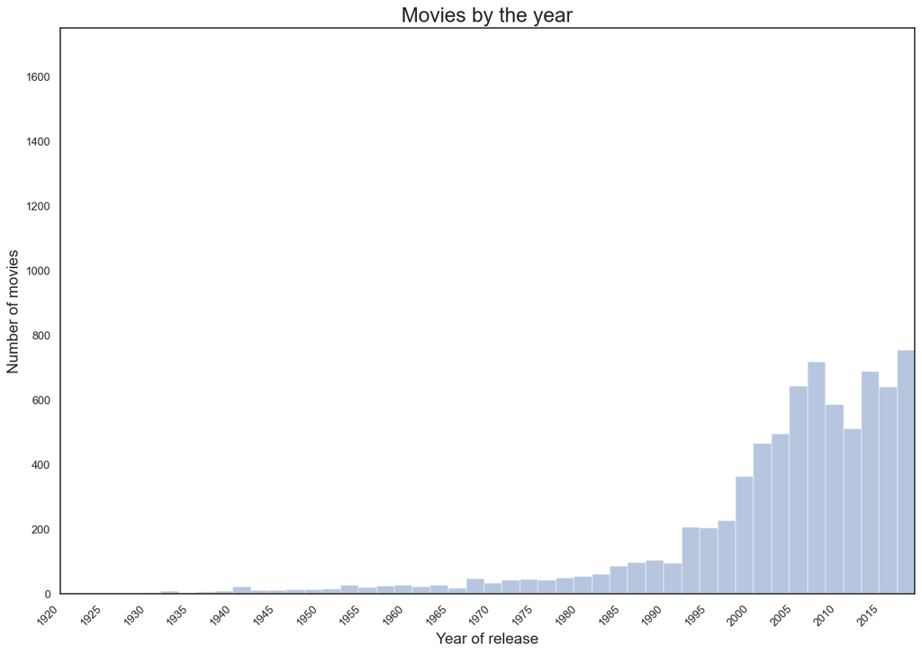

```python
movies_data = movies_data[movies_data.in_theaters_date.notnull()]
movies_data['in_theaters_date'] = pd.to_datetime(movies_data['in_theaters_date'])
movies_data['movie_year'] = movies_data['in_theaters_date'].apply(lambda x: x.year)

sns.set(style="white")

plt.figure(figsize=(15,10))
plt.title('Movies by the year', size=20)
sns.distplot(movies_data.movie_year, kde=False)
plt.ylabel('Number of movies', size=15)
plt.xlabel('Year of release',size=15)
plt.axis([1920, 2019, 0, 1750])
plt.xticks(np.arange(1920, 2018, step=5),rotation=45, ha='right')
plt.show()
```

# Distribution of TomatoMeter ratings across the years

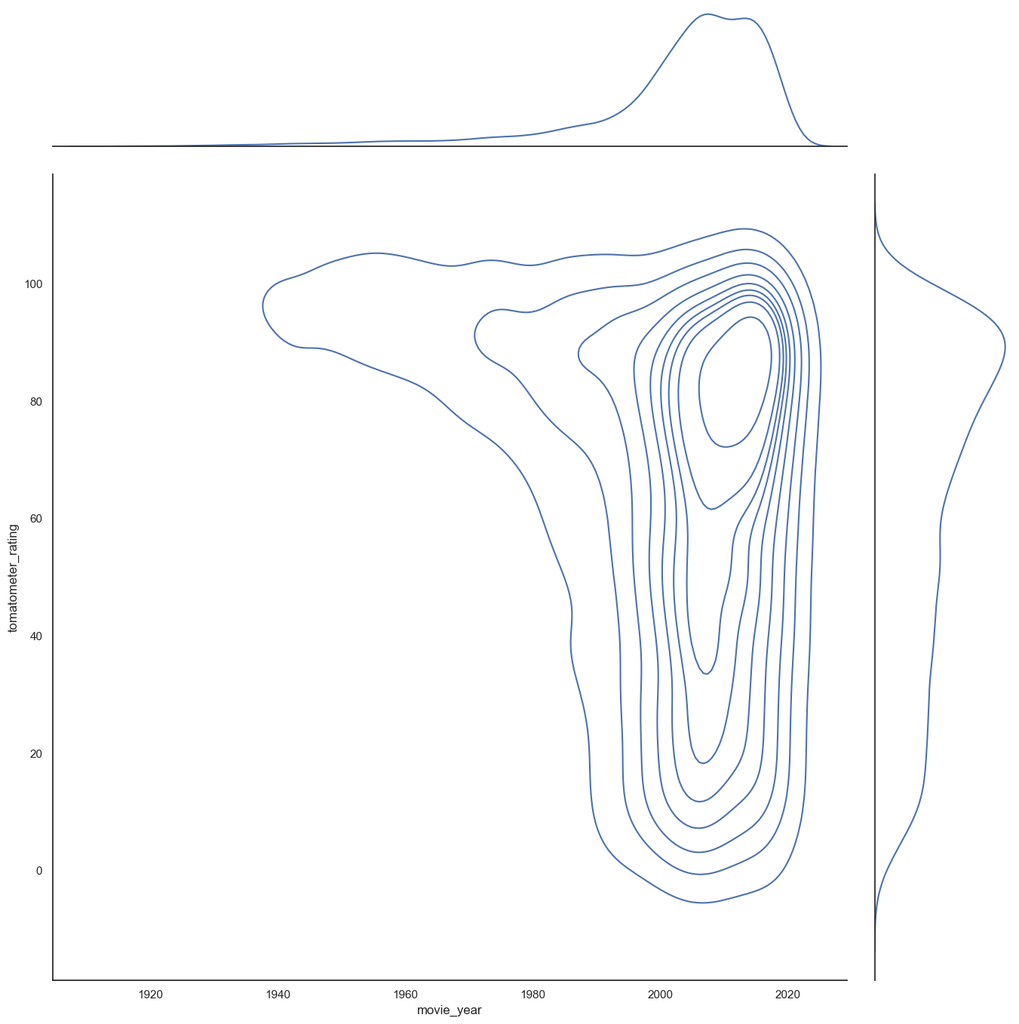

```python
movies_data = movies_data[(movies_data.tomatometer_rating.notnull()) &
                      (movies_data.audience_rating.notnull())]
sns.jointplot(x=movies_data['movie_year'], y=movies_data['tomatometer_rating'],
              kind="kde").fig.set_size_inches(15,15)
```

# Distribution of Audience ratings across the years

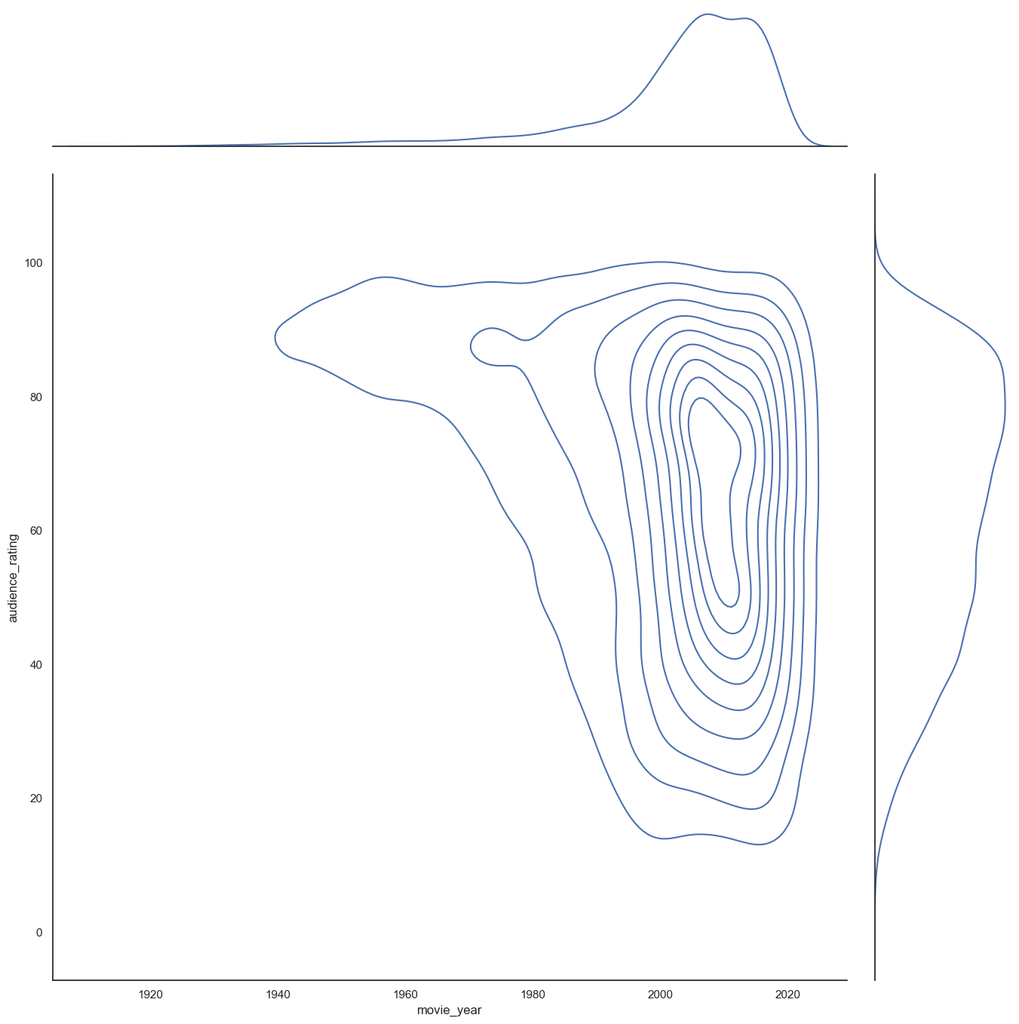

```python
sns.jointplot(x=movies_data['movie_year'], y=movies_data['audience_rating'],
              kind="kde").fig.set_size_inches(15,15)
```

# Frequency of Studio names

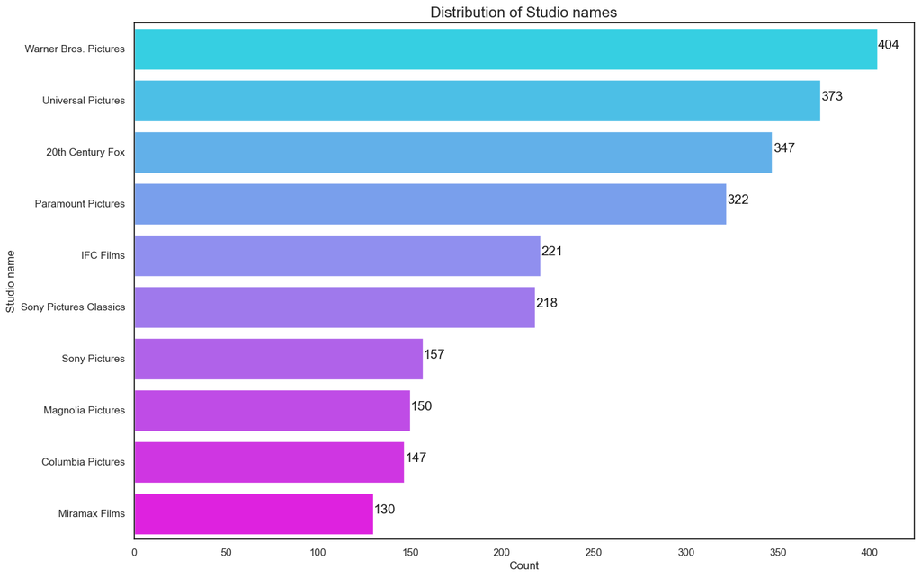

```python
a = plt.cm.cool

plt.figure(figsize=(15,10))
count = movies_data['studio_name'].value_counts()[:10]
sns.barplot(x=count.values, y=count.index, palette=[a(0.1),a(0.2),a(0.3),a(0.4),a(0.5),a(0.6),a(0.7),a(0.8),a(0.9),a(0.99)])
for i, v in enumerate(count.values):
    plt.text(v + 0.5,i,str(v),color='k',fontsize=14)
plt.xlabel('Count', fontsize=12)
plt.ylabel('Studio name', fontsize=12)
plt.title("Distribution of Studio names", fontsize=16)
plt.show()
```

# Frequency of movie genres

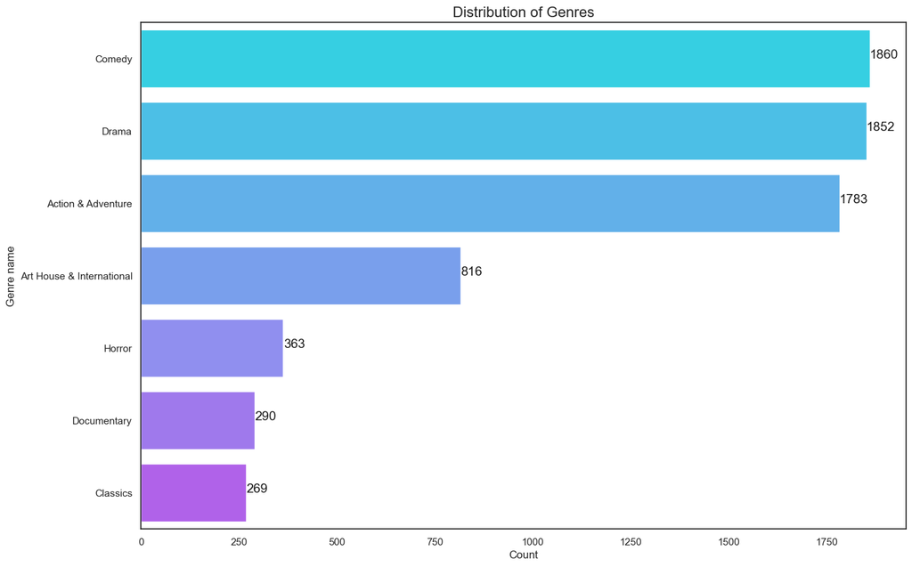

```python
movies_data['first_genre'] = movies_data['genre'].str.split(',').str[0]

a = plt.cm.cool

plt.figure(figsize=(15,10))
count = movies_data['first_genre'].value_counts()[:7]
sns.barplot(x=count.values, y=count.index, palette=[a(0.1),a(0.2),a(0.3),a(0.4),a(0.5),a(0.6),a(0.7)])
for i, v in enumerate(count.values):
    plt.text(v + 0.5,i,str(v),color='k',fontsize=14)
plt.xlabel('Count', fontsize=12)
plt.ylabel('Genre name', fontsize=12)
plt.title("Distribution of Genres", fontsize=16)
plt.show()
```

# Boxplot of TomatoMeter and Audience ratings grouped by genre

```python
movies_data.head(1)
```

|  | movie_title | movie_info | critics_consensus | rating | genre | directors | writers | cast | in_theaters_date | on_streaming_date | runtime | studio_name | tomatometer_status | tomatometer_rating | tomatometer_count | audience_rating | rating_diff | rating_diff_abs | movie_year | first_genre |
| --- | --- | --- | --- | --- | --- | --- | --- | --- | --- | --- | --- | --- | --- | --- | --- | --- | --- | --- | --- | --- |
| 0 | Percy Jackson & the Olympians: The Lightning T... | A teenager discovers he's the descendant of a ... | Though it may seem like just another Harry Pot... | PG | Action & Adventure, Comedy, Drama, Science Fic... | Chris Columbus | Craig Titley | Logan Lerman, Brandon T. Jackson, Alexandra Da... | 2010-02-12 | 2010-06-29 | 83 | 20th Century Fox | Rotten | 49 | 144 | 53 | 4 | 4 | 2010 | Action & Adventure |

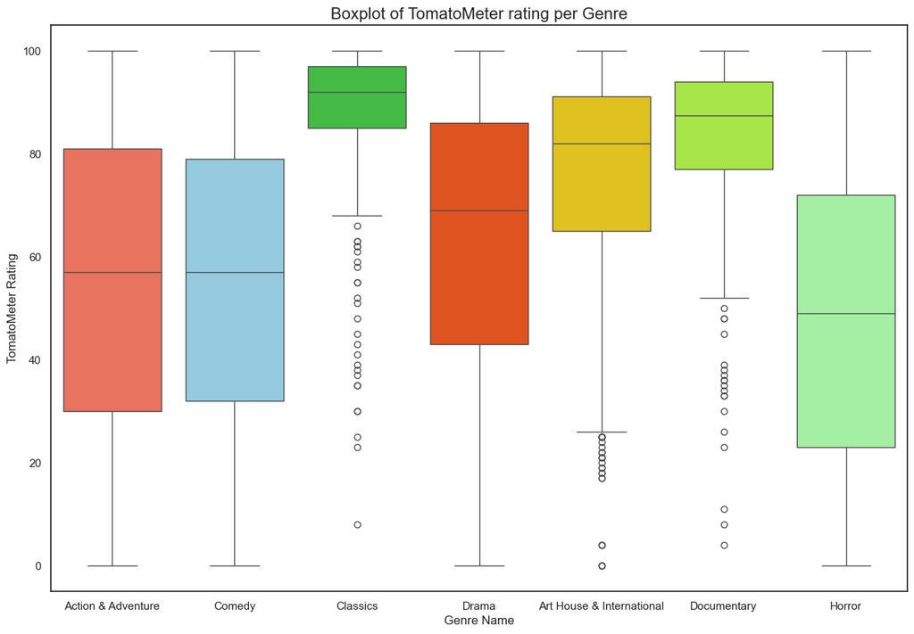

```python
custom_palette = ['#FF6347', '#87CEEB', '#32CD32', '#FF4500', '#FFD700', '#ADFF2F', '#98FB98', '#FF1493', '#8A2BE2', '#A52A2A']
top_genres = list(count.index)
movie_genres_df = movies_data[movies_data['first_genre'].isin(top_genres)]
movie_genres_df = movie_genres_df[pd.notnull(movie_genres_df[['first_genre', 'tomatometer_rating', 'tomatometer_status', 'tomatometer_count',
                                                              'audience_rating']])]

plt.figure(figsize=(15, 10))
sns.boxplot(x='first_genre', y='tomatometer_rating', data=movie_genres_df,palette=custom_palette)
plt.xlabel("Genre Name",fontsize=12)
plt.ylabel("TomatoMeter Rating",fontsize=12)
plt.title("Boxplot of TomatoMeter rating per Genre", fontsize=16)
```

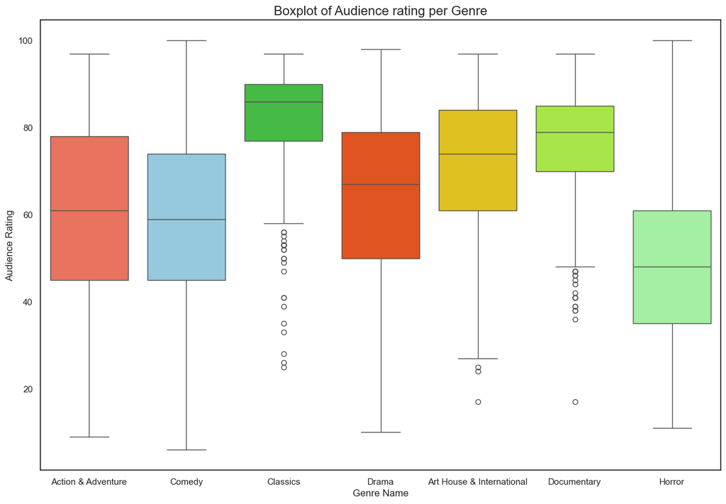

```python
plt.figure(figsize=(15, 10))
sns.boxplot(x='first_genre', y='audience_rating', data=movie_genres_df,palette=custom_palette)
plt.xlabel("Genre Name",fontsize=12)
plt.ylabel("Audience Rating",fontsize=12)
plt.title("Boxplot of Audience rating per Genre", fontsize=16)
plt.show()
```

# Crosstab of genres and TomatoMeter and Audience status

```python
genre_rating_tomatometer = pd.crosstab(movie_genres_df.first_genre, movie_genres_df.tomatometer_status, margins=True)
genre_rating_tomatometer.style.background_gradient(cmap='summer_r')
```

| tomatometer_status first_genre | Certified Fresh | Fresh | Rotten | All |
| --- | --- | --- | --- | --- |
| Action & Adventure | 490 | 362 | 931 | 1783 |
| Art House & International | 393 | 264 | 159 | 816 |
| Classics | 121 | 128 | 20 | 269 |
| Comedy | 496 | 389 | 975 | 1860 |
| Documentary | 173 | 91 | 26 | 290 |
| Drama | 714 | 400 | 738 | 1852 |
| Horror | 60 | 81 | 222 | 363 |
| All | 2447 | 1715 | 3071 | 7233 |

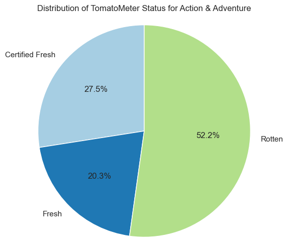

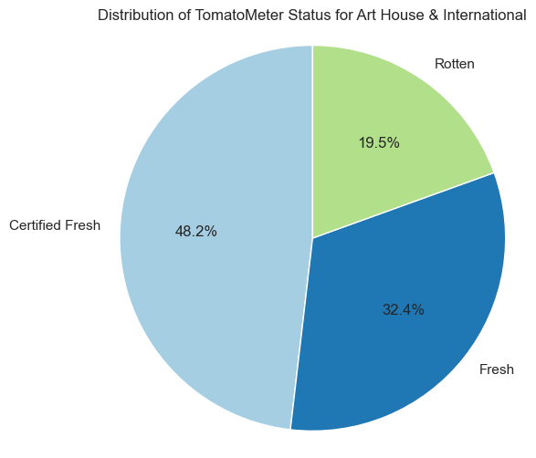

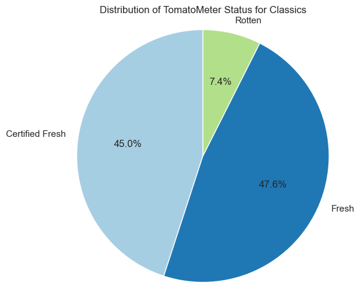

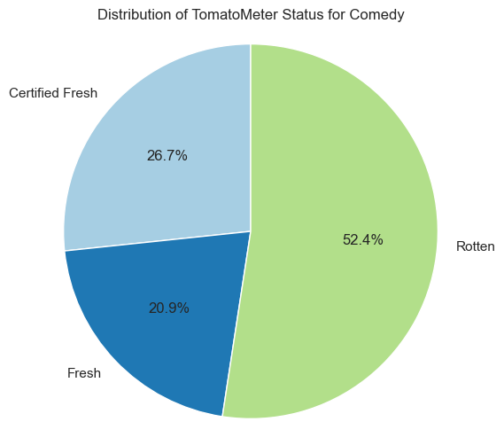

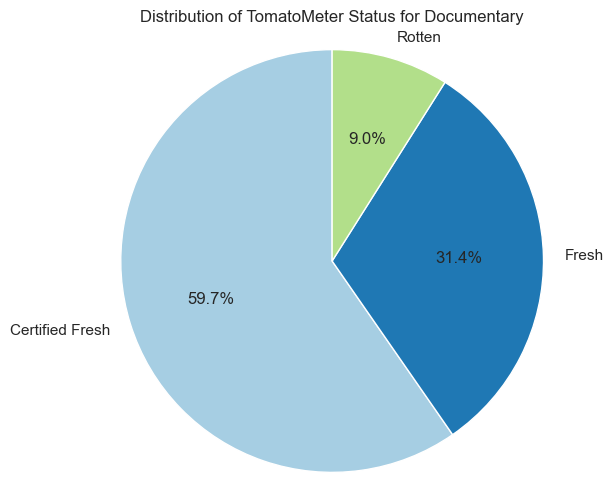

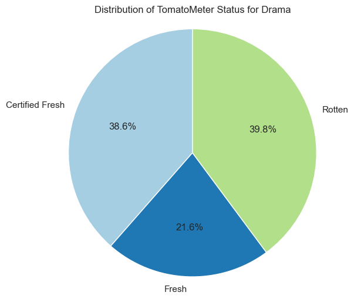

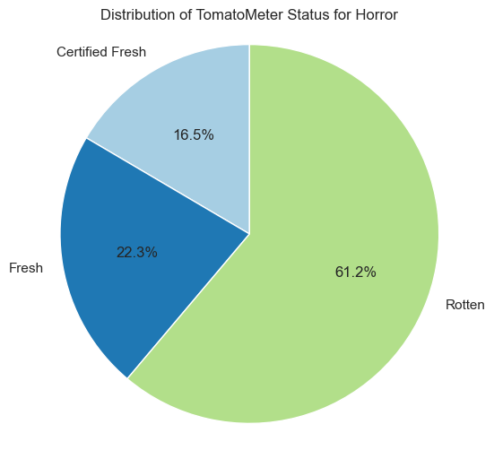

```python
 #Create a crosstab of first_genre vs tomatometer_status
genre_rating_tomatometer = pd.crosstab(movie_genres_df.first_genre, movie_genres_df.tomatometer_status, margins=True)

# Loop through each genre and create a pie chart for the distribution of tomatometer_status
for genre in genre_rating_tomatometer.index[:-1]:  # Excluding the last row (margins)
    genre_data = genre_rating_tomatometer.loc[genre]  # Get data for a single genre
    genre_data = genre_data.drop('All')  # Remove the 'All' column

    # Plotting the pie chart for this genre
    plt.figure(figsize=(6, 6))
    plt.pie(genre_data, labels=genre_data.index, autopct='%1.1f%%', startangle=90, colors=plt.cm.Paired.colors)
    plt.title(f'Distribution of TomatoMeter Status for {genre}')
    plt.axis('equal')  # Equal aspect ratio ensures that pie is drawn as a circle
    plt.show()
```

[output not shown]

[figure not shown]

```python
f,ax = plt.subplots(3,1, figsize=(15, 30))
sns.distplot(movie_genres_df[(movie_genres_df['tomatometer_status'] == 'Certified-Fresh') &
                             (movie_genres_df['tomatometer_count'] <= 400)].tomatometer_count, ax=ax[0], bins=30)
ax[0].set_title('TomatoMeter count in Certified Fresh', fontsize=16)
ax[0].set_xlabel("TomatoMeter Count",fontsize=12)
ax[0].set_xlim([0,400])
sns.distplot(movie_genres_df[(movie_genres_df['tomatometer_status'] == 'Fresh') &
                             (movie_genres_df['tomatometer_count'] <= 400)].tomatometer_count, ax=ax[1], bins=30)
ax[1].set_title('TomatoMeter count in Fresh', fontsize=16)
ax[1].set_xlabel("TomatoMeter Count",fontsize=12)
ax[1].set_xlim([0,400])
sns.distplot(movie_genres_df[(movie_genres_df['tomatometer_status'] == 'Rotten') &
                             (movie_genres_df['tomatometer_count'] <= 400)].tomatometer_count, ax=ax[2], bins=30)
ax[2].set_title('TomatoMeter count in Rotten', fontsize=16)
ax[2].set_xlabel("TomatoMeter Count",fontsize=12)
ax[2].set_xlim([0,400])
plt.show()
```

# Pie chart of Genres and relative TomatoMeter status - credit to Marco Zanella for the code

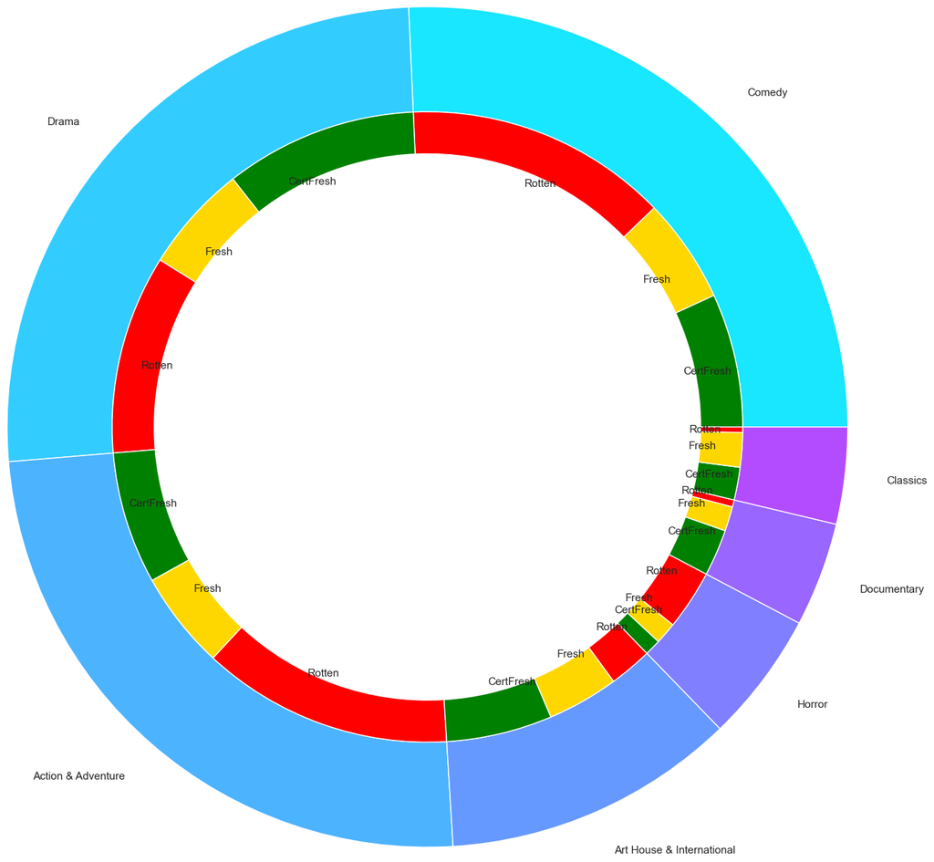

```python
group_names = movie_genres_df.first_genre.value_counts().head(7).index
group_size = movie_genres_df.first_genre.value_counts().head(7)
subgroup_names = ['CertFresh','Fresh','Rotten', 'CertFresh','Fresh','Rotten', 'CertFresh','Fresh','Rotten', 'CertFresh', 'Fresh', 'Rotten',
                  'CertFresh','Fresh','Rotten', 'CertFresh','Fresh','Rotten', 'CertFresh','Fresh','Rotten']
size_list = []
for element in group_names:
    size_list.append(genre_rating_tomatometer.loc[element]['Certified Fresh'])
    size_list.append(genre_rating_tomatometer.loc[element]['Fresh'])
    size_list.append(genre_rating_tomatometer.loc[element]['Rotten'])
subgroup_size = size_list

fig, ax = plt.subplots()
ax.axis('equal')
outter_pie, _ = ax.pie(group_size, radius=4, labels=group_names,
                       colors=[a(0.1),a(0.2),a(0.3),a(0.4),a(0.5),a(0.6),a(0.7)])
plt.setp(outter_pie, width=1, edgecolor='white')
inner_pie, _ = ax.pie(subgroup_size, radius=3, labels=subgroup_names, labeldistance=0.83,
                      colors=['green','gold','red', 'green','gold','red', 'green','gold','red', 'green','gold','red',
                              'green','gold','red', 'green','gold','red', 'green','gold','red'])
plt.setp(inner_pie, width=0.4, edgecolor='white')
plt.margins(0,0)
plt.show()
```

```python
movies_data.head(1)
```

|  | movie_title | movie_info | critics_consensus | rating | genre | directors | writers | cast | in_theaters_date | on_streaming_date | runtime | studio_name | tomatometer_status | tomatometer_rating | tomatometer_count | audience_rating | rating_diff | rating_diff_abs | movie_year | first_genre |
| --- | --- | --- | --- | --- | --- | --- | --- | --- | --- | --- | --- | --- | --- | --- | --- | --- | --- | --- | --- | --- |
| 0 | Percy Jackson & the Olympians: The Lightning T... | A teenager discovers he's the descendant of a ... | Though it may seem like just another Harry Pot... | PG | Action & Adventure, Comedy, Drama, Science Fic... | Chris Columbus | Craig Titley | Logan Lerman, Brandon T. Jackson, Alexandra Da... | 2010-02-12 | 2010-06-29 | 83 | 20th Century Fox | Rotten | 49 | 144 | 53 | 4 | 4 | 2010 | Action & Adventure |

```python
len(movies_data)
```

```
7610
```

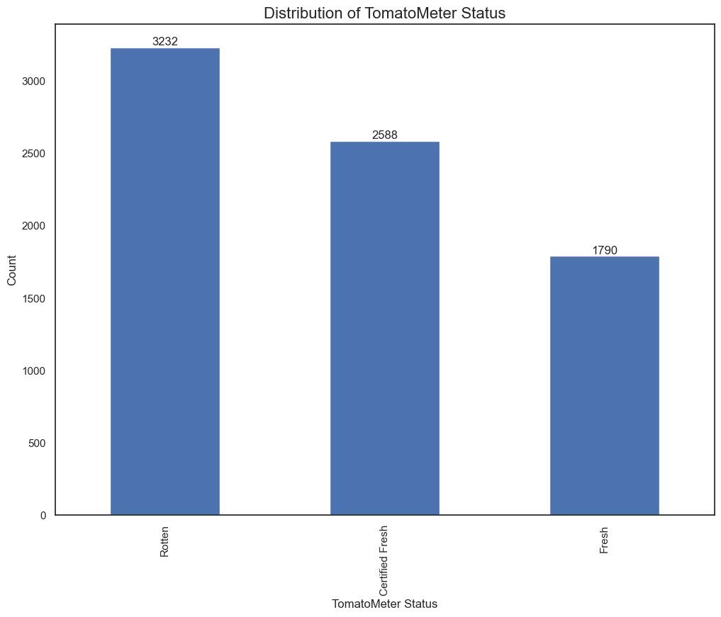

```python
# Plot the bar chart with proper figsize placement
ax = movies_data.tomatometer_status.value_counts().plot(kind='bar', figsize=(12, 9))

# Add labels to the bars
ax.bar_label(ax.containers[0])

# Optional: Add a title and labels for better visualization
ax.set_title("Distribution of TomatoMeter Status", fontsize=16)
ax.set_xlabel("TomatoMeter Status", fontsize=12)
ax.set_ylabel("Count", fontsize=12)

# Display the plot
plt.show()
```

# Model Evaluation

```python
from sklearn.model_selection import train_test_split
from sklearn.metrics import accuracy_score, classification_report
from sklearn.linear_model import LogisticRegression
from sklearn.ensemble import RandomForestClassifier
from sklearn.metrics import classification_report
from sklearn.metrics import confusion_matrix
```

The EDA of the dataset reveals that the "tomatometer" status, categorized as "fresh," "rotten," or "certified," varies across different genres. Visualizations show that certain genres are more likely to have higher "fresh" ratings, while others lean toward "rotten." This analysis provides valuable insights into how movie genres relate to review scores.

```python
# Define X (feature data) and y (target data)
X = movies_data.drop(['tomatometer_status', 'runtime'], axis=1)
y = movies_data['tomatometer_status']
```

```python
X_train, X_test, y_train, y_test = train_test_split(X, y, test_size=0.2, random_state=42)
```

```python
from sklearn.feature_extraction.text import TfidfVectorizer
 #Create TF-IDF vectorizer for text features
vectorizer = TfidfVectorizer(stop_words='english')
```

```python
# Fit vectorizer to training data and transform both training and testing data
X_train_tfidf = vectorizer.fit_transform(X_train['movie_info'])
X_test_tfidf = vectorizer.transform(X_test['movie_info'])
```

```python
# Train a random forest classifier on the transformed data
rf = RandomForestClassifier(n_estimators=100, random_state=42)
rf.fit(X_train_tfidf, y_train)
```

```
RandomForestClassifier(random_state=42)
```

```python
# Evaluate model performance on testing data
y_pred = rf.predict(X_test_tfidf)
print('Accuracy:', accuracy_score(y_test,y_pred))
```

```
Accuracy: 0.511826544021025
```

```python
print(classification_report(y_test, y_pred))
confusion_matrix(rf, X_test, y_test)
```

```
                 precision    recall  f1-score   support

Certified Fresh       0.48      0.43      0.45       489
          Fresh       0.67      0.01      0.02       358
         Rotten       0.53      0.83      0.64       675

       accuracy                           0.51      1522
      macro avg       0.56      0.43      0.37      1522
   weighted avg       0.54      0.51      0.44      1522
```

[output not shown]